# Questions asked in Philosophy

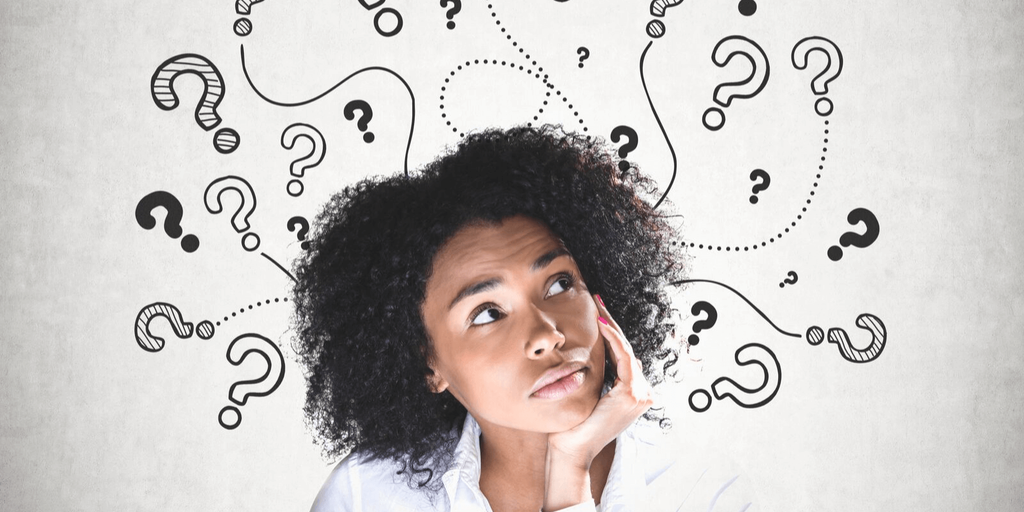

### Name: Joel Mugyenyi

### UNI: jm5352

```python
# import libaries
import pandas as pd
import matplotlib.pyplot as plt
import seaborn as sns
from sklearn.feature_extraction.text import TfidfVectorizer
color = 'steelblue' # set plot color
```

## About Data

The dataset contains over 300,000 sentences from texts/books across 13 schools of philosophy. The schools are; Plato, Aristotle, Rationalism, Empiricism, German Idealism, Communism, Capitalism, Phenomenology, Continental Philosophy, and Analytic Philosophy.

The dataset has already been cleaned and the variables include are; text title, author, school, full sentences, original text publication date, corpus edition date, sentence length, tokenzined and lemmatized versions of the sentences.

```python
# load dataset
df = pd.read_csv('../data/philosophy_data.csv')
```

Philosophy as defined on [wikipedia](https://en.wikipedia.org/wiki/Philosophy) is the study of general and fundamental questions, such as those about existence, reason, knowledge, values, mind, and language.

In our dataset, we shall explore the questions asked by the authors of these texts to learn want they reveal about the authors and the schools of philosophy in which they are categorized.

We start by filtering out which sentences are questions and which aren't. We rely on the sentence Punctuation to determine which sentences are questions and which are not. Sentences that end with question marks are categorized as questions and those that do not are not questions.

```python
def is_question(sentence):
    '''
    Function to determine if a sentence is a question or not.
    '''
    if '?' in sentence:
        return("QN")
    else:
        return("Not_QN")

# A new column is added to the dataset indicating which sentences are questions and which are not.
df['is_question'] = df.sentence_str.apply(is_question)
```

Next we explore the number of questions asked in each Philosophy school. We are not taking the context of the questions into considerations just yet but rather the proportion of a given text's sentences that are questions.

```python
# Taking a count of the number of sentences per text that are questions and not questions
df_qn = df[df.is_question=='QN'] # dataframe of sentences that are questions
df_not_qn = df[df.is_question=='Not_QN'] # dataframe of sentences that are not questions

# Group by titles
df_not_qn_count = df_not_qn.groupby(['title'])['is_question'].count().reset_index()
# Add proper column headers
df_not_qn_count = df_not_qn_count.rename(columns={"is_question": "not_question"})
df_qn_count = df_qn.groupby(['title'])['is_question'].count().reset_index()
# calculate the percentage of a given text's sentences that are questions
df_qn_percent = df_qn_count.merge(df_not_qn_count, how='left', on='title')
df_qn_percent['qn_percentage'] = (df_qn_percent.is_question/(df_qn_percent.is_question
                                                             + df_qn_percent.not_question))*100
df_qn_percent = df_qn_percent.sort_values(by=['qn_percentage'], ascending=False)


# Formating final dataframe
df_qn_perct_schools = df_qn_percent.merge(df[['title','school']], how='left', on='title')
df_qn_perct_schools.head(2)
```

|  | title | is_question | not_question | qn_percentage | school |
| --- | --- | --- | --- | --- | --- |
| 0 | Three Dialogues | 472 | 1222 | 27.863046 | empiricism |
| 1 | Three Dialogues | 472 | 1222 | 27.863046 | empiricism |

Looking at the percentage of questions asked per text by philosophy school, we start to notice some interesting trends.

*scatter plot*: Looking at the extreme ends of the plot, we notice that capitalism and communism tend to ask the fewest questions while schools on the other end of the plot namely; empiricism and analytic philosophy ask the highest proportion of questions. OfCourse, we don't yet know the context of the question but we can infer that probably capitalism and communism are more "lecture" oriented while empiricism and analytic philosophy are more geared towards "discovery". It is important to note that empiricism and analytic philosophy have more texts in our dataset than communism or capitalism.

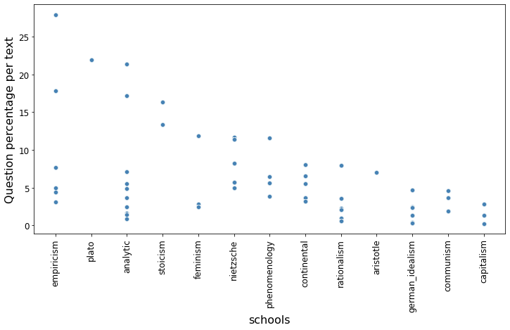

```python
plt.rcParams["figure.figsize"] = (12,6)


ax = sns.scatterplot(data=df_qn_perct_schools, x="school", y="qn_percentage",
                 color=color)
plt.xlabel('schools', fontsize=16)
plt.ylabel('Question percentage per text', fontsize=16)
plt.xticks(rotation = 90,fontsize=12)
plt.yticks(fontsize=12)
plt.show()
```

*Box plot*: When we focus on the distribution of the proportion of questions asked per text in each of the schools in our dataset, we notice limited variability in the capitalism and communism schools while schools on the other end namely empiricism and analytic philosophy have a wide variability

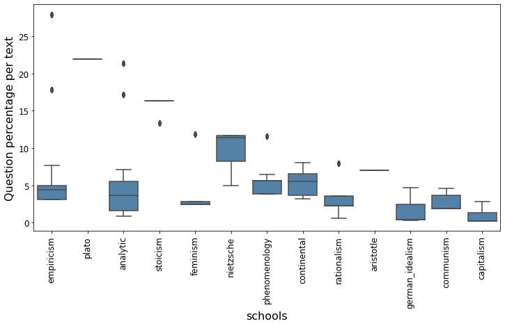

```python
plt.rcParams["figure.figsize"] = (12,6)


ax = sns.boxplot(data=df_qn_perct_schools, x="school", y="qn_percentage",
                 color=color,showmeans=False)
plt.xlabel('schools', fontsize=16)
plt.ylabel('Question percentage per text', fontsize=16)
plt.xticks(rotation = 90,fontsize=12)
plt.yticks(fontsize=12)
plt.show()
```

Given that the number of texts is unequal for each of the schools represented in the dataset. Let's take the median number of questions asked in each school to get a fairer comparison metric.

*Bar Chart*: A bar chart of the medians shows a high median for plato but since this school has only one text, we shall not consider it for our analysis. We notice that stoicism and nietzche tend to ask the most questions while communism, German idealism and capitalism ask the least proportion of questions

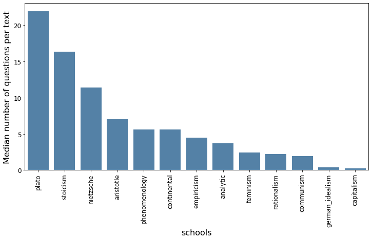

```python
df_qn_medians = df_qn_perct_schools.groupby(['school']
                                           )['qn_percentage'].median().reset_index().sort_values(
    by=['qn_percentage'], ascending=False)
plt.rcParams["figure.figsize"] = (12,6)
ax = sns.barplot(x="school", y="qn_percentage", data=df_qn_medians, color=color)
plt.xticks(rotation = 90,fontsize=12)
plt.yticks(fontsize=12)
plt.xlabel('schools', fontsize=16)
plt.ylabel('Median number of questions per text', fontsize=16)
plt.show()
```

## Nature of Questions asked

Next we unpack why stoicism and nietzsche ask so many questions as a percentage of text. We eliminate plato and aristotle even though they also ask a lot of questions simply because we only have a single text from each school.

Later we shall explore why communism, German idealism and capitalism ask so few questions as a proportion of the overall text

```python
# Import word cloud libraries
from wordcloud import WordCloud, STOPWORDS
```

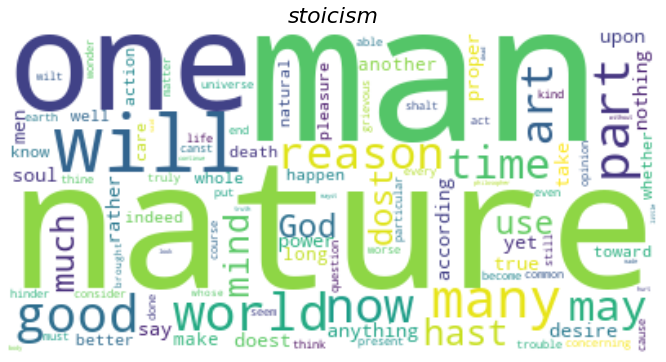

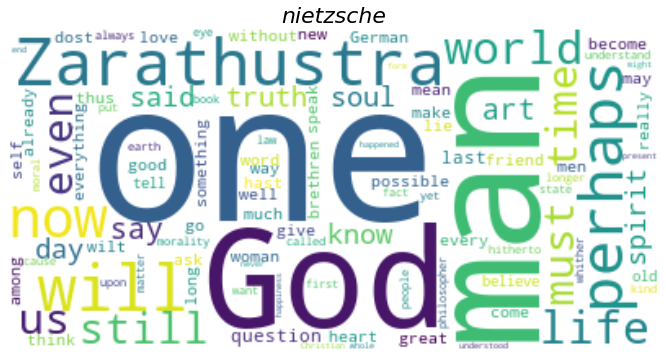

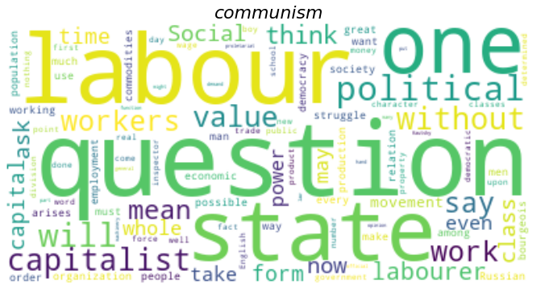

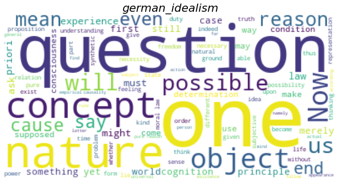

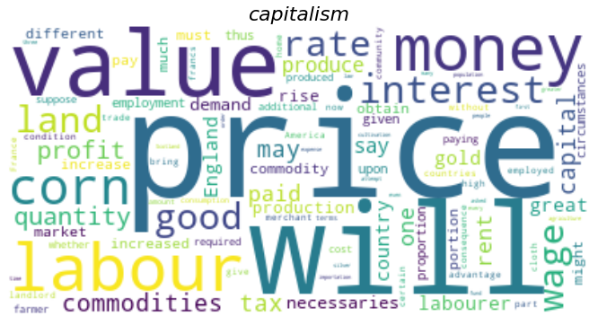

```python
# School of Interest
schools = ["stoicism", "nietzsche", "communism","german_idealism", "capitalism"]

for school in schools:
    school_qns = df[(df.school==school) & (df.is_question=='QN')]
    # Create stopword list:
    stopwords = set(STOPWORDS)
    stopwords.update(["unto", "thou", "doth", "thee", "either",
                      "thy","thyself","though", "hath", "ye","thing","things"])

    # school text
    text = " ".join(string for string in school_qns.sentence_str)

    # Create and generate a word cloud image:
    wordcloud = WordCloud(stopwords=stopwords, max_words=100, background_color="white").generate(text)

    # Display the generated image:
    plt.imshow(wordcloud, interpolation='bilinear')
    plt.axis("off")
    plt.title(f'{school}', fontsize=22,fontstyle='italic')
    plt.show()
```

Let's explore the words that stand out from stoicism. We shall also apply Term Frequency Inverse Document which is a technique used to measure how important a term is within a document relative to a collection of documents. All texts from a single school are classified as a single text for this exercise and compared against all the texts in our dataset.

# STOICISM

[figure not shown]

Starting with stoicism, let's discover the important words that are selected.

```python
# key words from questions asked in stoicism as identified by "WORD CLOUD"
stoicism_key_words = [" one ",' nature ',' man ',' will ',' many ',' good ', ' world ']
print(f"Key words from STOICISM as identified by 'WORD CLOUD': ")
for i,word in enumerate(stoicism_key_words):
    print(f"{i+1}: {word}")
```

```
Key words from STOICISM as identified by 'WORD CLOUD':
1:  one
2:  nature
3:  man
4:  will
5:  many
6:  good
7:  world
```

```python
# create TfidfVectorizer object
obj = TfidfVectorizer()

# get tf-idf values
stoc = df[df.school=='stoicism'].sentence_str.str.cat(sep=' ') # doc 1
combined = df.sentence_str.str.cat(sep=' ') # doc 2
result = obj.fit_transform([stoc], [combined])
feature_names = obj.get_feature_names_out()
dense = result.todense()
denselist = dense.tolist()

# get word score results
data_results_stoics = pd.DataFrame(denselist, columns=feature_names)
data_results_stoics = data_results_stoics.T.reset_index()
data_results_stoics = data_results_stoics.rename(columns={"index":"words",0:"score"})
data_results_stoics = data_results_stoics.sort_values(by=['score'], ascending=False)

stopwords = set(STOPWORDS)
stopwords.update(["unto", "thou", "doth", "thee", "either","thy","thyself","though",
                  "hath", "ye","thing","things","whatsoever","upon", "must"])

data_results_stoics = data_results_stoics[~(data_results_stoics.words.isin(stopwords))]
print(f"Key words from STOICISM as identified by 'TF-IDF process': ")
for i,word in enumerate(data_results_stoics.head(10).words.tolist()):
    print(f"{i+1}: {word}")
```

```
Key words from STOICISM as identified by 'TF-IDF process':
1: man
2: one
3: nature
4: will
5: good
6: now
7: world
8: may
9: mind
10: life
```

It can be observed that the top ten words from the TD-IDF process align closely with the top words from the word cloud.

When we research what stoicism is, we discover the stoicism is that philosophy of personal ethics informed by a system of logic and views on the natural world asserting that the practice of virtue is both necessary and sufficient to achieve flourishing by means of living an ethical life. according to this [wikipedia](https://en.wikipedia.org/wiki/Stoicism) article.

The article further goes on to state that stoics are known for teaching that "virtue is only good" for man and external influences like wealth and pleasure are not good or bad but just have value as "material for virtue to act upon. Stoics also believe people should maintain a will called prohairesis that is in accordance with nature. To live a good life, one has to understand the rules of the natural order since everything is rooted in nature.

# NIETZSCHE

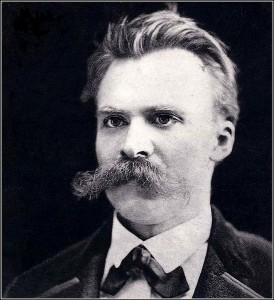

Next we apply the same process to nietzsche that we applied to stoicism, let's discover the important words that are selected.

```python
# key words from questions asked in nietzsche as identified by "WORD CLOUD"
nietzsche_key_words = [" one ",' GOD ',' man ',' Zarathustra ',' world ',' will ', ' life ']

print(f"Key words from NIETZSCHE as identified by 'WORD CLOUD': ")
for i,word in enumerate(nietzsche_key_words):
    print(f"{i+1}: {word}")
```

```
Key words from NIETZSCHE as identified by 'WORD CLOUD':
1:  one
2:  GOD
3:  man
4:  Zarathustra
5:  world
6:  will
7:  life
```

```python
# create TfidfVectorizer object
obj = TfidfVectorizer()

# get tf-df values
nietzsche = df[df.school=='stoicism'].sentence_str.str.cat(sep=' ') # doc 1
combined = df.sentence_str.str.cat(sep=' ') # doc 2
result = obj.fit_transform([nietzsche], [combined])
feature_names = obj.get_feature_names_out()
dense = result.todense()
denselist = dense.tolist()

# get word score results
data_results_nietzsche = pd.DataFrame(denselist, columns=feature_names)
data_results_nietzsche = data_results_nietzsche.T.reset_index()
data_results_nietzsche = data_results_nietzsche.rename(columns={"index":"words",0:"score"})
data_results_nietzsche = data_results_nietzsche.sort_values(by=['score'], ascending=False)

stopwords = set(STOPWORDS)
stopwords.update(["unto", "thou", "doth", "thee", "either","thy","thyself","though",
                  "hath", "ye","thing","things","whatsoever","upon", "must"])

data_results_nietzsche = data_results_nietzsche[~(data_results_nietzsche.words.isin(stopwords))]

print(f"Key words from NIETZSCHE as identified by 'TF-IDF process': ")
for i,word in enumerate(data_results_nietzsche.head(10).words.tolist()):
    print(f"{i+1}: {word}")
```

[output not shown]

Nietzche and stoicism both explore life and man's place in the world as well as how man should lead his life pursuant of good or bad (ethics and morals) or fulfilment. These are themes that do not have definite answers but rather require discussion and which an author will most likely achieve with a reader by posing questions for the reader to ponder and come to the same conclusion as the author or disagree.

# COMMUNISM

[figure not shown]

Let's explore schools that don't ask as many questions as a proportion of overall text starting with communism.

```python
# key words from questions asked in communism as identified by "WORD CLOUD"
communism_key_words = [" one ",' labour ',' state ',' work ',' political ',' class ', ' capitalist ', ' workers ']
print(f"Key words from COMMUNISM as identified by 'WORD CLOUD': ")
for i,word in enumerate(communism_key_words):
    print(f"{i+1}: {word}")
```

```
Key words from COMMUNISM as identified by 'WORD CLOUD':
1:  one
2:  labour
3:  state
4:  work
5:  political
6:  class
7:  capitalist
8:  workers
```

```python
# create TfidfVectorizer object
obj = TfidfVectorizer()

# get tf-df values
communism = df[df.school=='communism'].sentence_str.str.cat(sep=' ') # doc 1
combined = df.sentence_str.str.cat(sep=' ') # doc 2
result = obj.fit_transform([communism], [combined])
feature_names = obj.get_feature_names_out()
dense = result.todense()
denselist = dense.tolist()

# get word score results
data_results_communism = pd.DataFrame(denselist, columns=feature_names)
data_results_communism = data_results_communism.T.reset_index()
data_results_communism = data_results_communism.rename(columns={"index":"words",0:"score"})
data_results_communism = data_results_communism.sort_values(by=['score'], ascending=False)

stopwords = set(STOPWORDS)
stopwords.update(["unto", "thou", "doth", "thee", "either","thy","thyself","though",
                  "hath", "ye","thing","things","whatsoever","upon", "must"])

data_results_communism = data_results_communism[~(data_results_communism.words.isin(stopwords))]

print(f"Key words from COMMUNISM as identified by 'TF-IDF process': ")
for i,word in enumerate(data_results_communism.head(10).words.tolist()):
    print(f"{i+1}: {word}")
```

```
Key words from COMMUNISM as identified by 'TF-IDF process':
1: labour
2: value
3: one
4: capital
5: production
6: power
7: time
8: work
9: form
10: working
```

In this case, we observe the key words that we get from the TF-IDF process as well as from the word cloud are words commonly associated with communism and communist text such as "labour", "state", "production", "workers" or "class".

As defined on [wikipedia](https://en.wikipedia.org/wiki/Communism), communism is an ideology aiming to establish an order structured upon common ownership of the means of production and absence of social classes, money and the state.

Many of the key words like "production", "state", "class" can be seen in this definition indicating how our process are properly identifying the words that define the ideology.

# CAPITALISM

[figure not shown]

Lastly, we explore capitalism and the key words that define it

```python
# key words from questions asked in CAPITALISM  as identified by "WORD CLOUD"
capitalism_key_words = [" one ",' price ',' will ',' money ',' value ',' profit ', ' commodities ', ' capital ']

print(f"Key words from CAPITALISM as identified by 'WORD CLOUD': ")
for i,word in enumerate(capitalism_key_words):
    print(f"{i+1}: {word}")
```

```
Key words from CAPITALISM as identified by 'WORD CLOUD':
1:  one
2:  price
3:  will
4:  money
5:  value
6:  profit
7:  commodities
8:  capital
```

```python
# create TfidfVectorizer object
obj = TfidfVectorizer()

# get tf-df values
capitalism = df[df.school=='capitalism'].sentence_str.str.cat(sep=' ') # doc 1
combined = df.sentence_str.str.cat(sep=' ') # doc 2
result = obj.fit_transform([capitalism], [combined])
feature_names = obj.get_feature_names_out()
dense = result.todense()
denselist = dense.tolist()

# get word score results
data_results_capitalism = pd.DataFrame(denselist, columns=feature_names)
data_results_capitalism = data_results_capitalism.T.reset_index()
data_results_capitalism = data_results_capitalism.rename(columns={"index":"words",0:"score"})
data_results_capitalism = data_results_capitalism.sort_values(by=['score'], ascending=False)

stopwords = set(STOPWORDS)
stopwords.update(["unto", "thou", "doth", "thee", "either","thy","thyself","though",
                  "hath", "ye","thing","things","whatsoever","upon", "must"])

data_results_capitalism = data_results_capitalism[~(data_results_capitalism.words.isin(stopwords))]

print(f"Key words from CAPITALISM as identified by 'TF-IDF process': ")
for i,word in enumerate(data_results_capitalism.head(10).words.tolist()):
    print(f"{i+1}: {word}")
```

```
Key words from CAPITALISM as identified by 'TF-IDF process':
1: price
2: will
3: money
4: labour
5: value
6: great
7: capital
8: may
9: part
10: country
```

Capitalism has a few words in common with communism such as "labour", "value" and "capital". Capitalism key words are also words commonly associated with capitalism and capitalistic texts.

The [wikipedia](https://en.wikipedia.org/wiki/Capitalism) article on capitalism defines it as a system based on private ownership and control of the means of production with central traits such as capital accumulation, competitive markets and a price system determined by supply and demand.

# Conclusion

Communism and capitalism on the other hand deal with real world every day concepts such as production, class, and a country's politics and economy. The texts would therefore seek to prove that their ideology is teh right one and thus rather than pose questions to the readers, these schools would seek to persuade readers to view these everyday concepts from the author's viewpoint thus asking a number of questions in the text would not be helpful in achieving this objective.